# Homework Week2: SQL and R

Aaron Grzasko

September 11, 2016

## Assignment Overview

All survey data were initially stored in a MySQL database. The information was then retrieved from within the R environment and stored into R dataframes.

For additional practice, the author performed a variety of multiple data manipulation and summarization tasks.

## Data

A variety of data sources were used in this assignment:

- Movie metrics (including genre, box office revenue year-to-date, MPAA ratings, etc.) were retrieved from [boxofficemojo.com](http://www.boxofficemojo.com/yearly/chart/?yr=2016). Metrics involving box office revenue ostensbily were current as of 9/8/2016.
- IMDB average user ratings for movies were retrived from the [IMDB.com](http://www.imdb.com/).
- Additional movie rating and commentary data were obtained through informal polling of friends and family. The names and demographic attributes of the survey particpants have been altered. Survey data were also augmented with dummy data rendered entirely from the author’s imagination.

## R References

The author referenced the following R resources to complete the assignment:

- [MySQL and R](https://www.r-bloggers.com/mysql-and-r/): used to supplement understanding of `dbConnect()` and `dbGetQuery()` functions.
- [getPass](https://cran.r-project.org/web/packages/getPass/getPass.pdf): used `getPass()` function in code so that username and password data were not explicitly reference in R Markdown document.

## Data Retrieval

**Load R Packages**

First, load relavent libraries:

```r
# Uncomment scripts below if packages are not already installed

#install.packages('RMySQL')
#install.packages('getPass')

library(RMySQL)
library(getPass)
```

**Retrieve and Store Database Tables, Overview**  
Data are initially stored in a MySQL database, *movie_ratings*.

The database contains three tables:  
- movies  
- raters  
- rating_survey

The SQL script used to create the database–*movie_tables.sql*–is stored in the the author’s Github repository for reference.

For the purposes of this assignment, the author assumes that only a subset of the data in the MySQL is relevant to this exercise. Specifically, the author assumes that the *movies*, and *raters* tables are required in their entirety, but only a subset of the *rating_survey* survey data is necessary. The author combines the relevant survey_data information with additional, relevant data from the other two tables.

**DB Connectivity**

```r
# MySQL connection.  Using getPass() function to prompt user for username and password
my_db = dbConnect(MySQL(), user=getPass(msg = 'Enter username'), password= getPass('Enter Password'), dbname='movie_ratings')
#on.exit(dbDisconnect(my_db))
```

**Retrieve and Store Data in R DataFrames**  
Note: Box office revenue (both domestic and worldwide) and production budgets in the movies table are presented in $ Millions.

```r
# movie table
sql_movies <- "Select * FROM movies;"
movies.df <- dbGetQuery(my_db, sql_movies)
knitr::kable(movies.df)
```

| movie_id | title | genre | dom_box_office | world_box_office | studio | mpaa_rating | prod_budg | imdb_rating | open_dt | close_dt |
| --- | --- | --- | --- | --- | --- | --- | --- | --- | --- | --- |
| 1 | Hilary’s America | Documentary | 13 | 13 | Quality Flix | PG-13 | NA | 5.9 | 2016-07-15 | NA |
| 2 | The Jungle Book | Adventure | 364 | 964 | Buena Vista | PG | 175 | 7.7 | 2016-04-15 | NA |
| 3 | Deadpool | Action | 363 | 783 | Fox | R | 58 | 8.1 | 2016-02-12 | 2016-06-16 |
| 4 | Finding Dory | Animation | 483 | 945 | Buena Vista | PG | 200 | 7.8 | 2016-06-17 | NA |
| 5 | Central Intelligence | Comedy | 127 | 214 | Warner Bros | PG-13 | 50 | 6.5 | 2016-06-17 | 2016-09-01 |
| 6 | Bad Moms | Comedy | 106 | 144 | STX Entertainment | R | 20 | 6.7 | 2016-07-29 | NA |

```r
# raters table
sql_raters <- "Select * FROM raters;"
raters.df <- dbGetQuery(my_db, sql_raters)
knitr:: kable(raters.df)
```

| rater_id | last_name | first_name | gender | dob | occupation | zip |
| --- | --- | --- | --- | --- | --- | --- |
| 1 | Johnston | Marcus | M | 1977-01-28 | Chef | 16854 |
| 2 | Chadwick | Bobby | M | 1980-12-14 | Doctor | 16501 |
| 3 | Johnston | Lucy | F | 2005-08-05 | Student | 16854 |
| 4 | Grasso | Beth | F | 1978-10-01 | Engineer | 14200 |
| 5 | Smith | Paul | M | 1945-05-07 | Lawyer | 16803 |
| 6 | Smith | Babs | F | 1946-03-24 | Retired | 16803 |

```r
# rating_survey subset combined with data from other two tables
sql_ratings <- "SELECT CONCAT(first_name, ' ', last_name) AS critic, title, rating, comments
                    FROM movies
                    INNER JOIN rating_survey
                    ON movies.movie_id =  rating_survey.movie_id
                    INNER JOIN raters
                    ON rating_survey.rater_id = raters.rater_id;"

ratings.df <- dbGetQuery(my_db, sql_ratings)

# head of rating table
knitr:: kable(head(ratings.df,10))
```

| critic | title | rating | comments |
| --- | --- | --- | --- |
| Marcus Johnston | Hilary’s America | 2 | Entertaining but it’s a work of fiction |
| Marcus Johnston | The Jungle Book | 3 | My kid loved it; so I can’t hate it |
| Marcus Johnston | Deadpool | 5 | Intense! |
| Marcus Johnston | Finding Dory | 4 | Pretty good for a cartoon |
| Marcus Johnston | Central Intelligence | 4 | Freakin’ Hilarious |
| Marcus Johnston | Bad Moms | 3 | I thought it was a chick flick, but it’s not |
| Bobby Chadwick | Hilary’s America | 1 | Why did I pay 10 bucks to see this crap? |
| Bobby Chadwick | The Jungle Book | 4 | Loved the CGI. |
| Bobby Chadwick | Deadpool | 5 | I love superhero movies! |
| Bobby Chadwick | Finding Dory | 4 | Loved the message of this movie! |

## Data Manipulation and Summaries

**Rating Summaries by Movie**  
Let’s look at the mean survey rating by movie. We’ll ignore any NA values.

```r
avg_mov_rating <-setNames(aggregate(ratings.df$rating, list(ratings.df$title),mean,na.rm = TRUE),c("title","rating"))
avg_mov_rating$rating <-round(avg_mov_rating$rating,2)
knitr::kable(avg_mov_rating)
```

| title | rating |
| --- | --- |
| Bad Moms | 3.75 |
| Central Intelligence | 3.00 |
| Deadpool | 3.75 |
| Finding Dory | 4.20 |
| Hilary’s America | 2.67 |
| The Jungle Book | 4.00 |

Now, let’s combine our survey rating averages with IMDB survey averages.  
Before we can do this, we’ll need to scale the IMDB ratings to be on a scale of one to five, instead of one to ten.

```r
# scale imdb ratings
movies.df$imdb_scaled_rat <- movies.df$imdb_rating / 2

# merge and compare survey and imdb ratings
ratings_compare <-subset(merge(avg_mov_rating,movies.df, by="title"), select = c(title,rating, imdb_scaled_rat))
ratings_compare$diff <- ratings_compare$rating - ratings_compare$imdb_scaled_rat
knitr:: kable(ratings_compare)
```

| title | rating | imdb_scaled_rat | diff |
| --- | --- | --- | --- |
| Bad Moms | 3.75 | 3.35 | 0.40 |
| Central Intelligence | 3.00 | 3.25 | -0.25 |
| Deadpool | 3.75 | 4.05 | -0.30 |
| Finding Dory | 4.20 | 3.90 | 0.30 |
| Hilary’s America | 2.67 | 2.95 | -0.28 |
| The Jungle Book | 4.00 | 3.85 | 0.15 |

Generally speaking, the survey mean ratings do not apear to be drastically different than the imdb ratings. If we wanted to get more technical, we could use t tests to determine statistical signficance of the differences in means for each movie.

**Rating Summary by Reviewer**

Let’s now calculate the average movie rating per survey participant:

```r
avg_critic <-setNames(aggregate(ratings.df$rating, list(ratings.df$critic),mean, na.rm = TRUE),c("critic","rating"))
avg_critic$rating <- round(avg_critic$rating,2)
knitr:: kable(avg_critic)
```

| critic | rating |
| --- | --- |
| Babs Smith | 3.83 |
| Beth Grasso | 2.00 |
| Bobby Chadwick | 3.80 |
| Lucy Johnston | 4.00 |
| Marcus Johnston | 3.50 |
| Paul Smith | 3.83 |

Finally, let’s produce bar plots of ratings distribution for each survey participant. We will ignore all NAs:

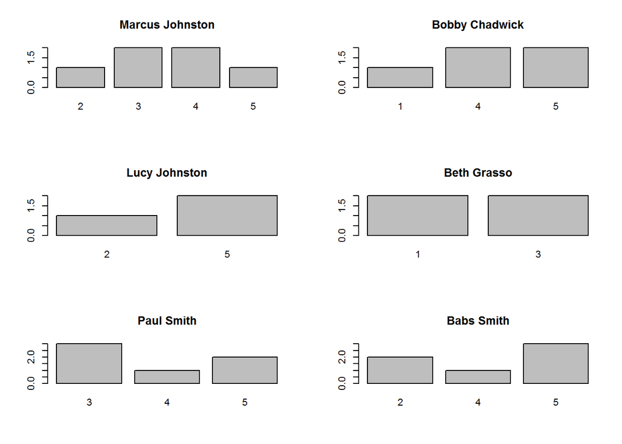

```r
par(mfrow = c(3,2))
for (i in unique(ratings.df$critic)){
    barplot(table(ratings.df[ratings.df$critic == i,]$rating), main = i)
}
```

The graphs are not too revealing, given the small sample size of movies for each participant. However, these graphs would likely be very useful if had asked each participant to review more movies.